# Dada2_report

Eily via Moncho

November 18, 2021

### MiFish / MiMammal: 150/150

### COI: 250/200

### but double check them with quality plot visualizations

## Dada2 report

You have successfully used `cutadapt` to split the .FASTQ files by locus and remove the primer sequence. Not a small feat. Now we are going to apply a denoising algorithm `DADA2`, https://github.com/benjjneb/dada2, and estimate the original sample composition. On the parameters section you have chosen a trimming length for each of the two files, whether to use Hashes or not, and a folder where to drop the output files

First load the packages. And let’s update the parameters we need

```r
library(here)
library (tidyverse)
library (dada2)
library (digest)
library (seqinr)
library (knitr)
library (kableExtra)

sample.metadata <- read_csv(params$metadata)
filt_path <- file.path(params$folder, "filtered")
getwd()
```

```
## [1] "/Users/elizabethandruszkiewicz/GoogleDrive/UW/GitHub/NextGenNEPA_EA/Output/cutadapt_output/run3_20211117/noprimers/COI"
```

```r
filt_path
```

```
## character(0)
```

```r
# Check if output directory exists - if not create as a subfolder of input dir
if(!dir.exists(file.path(params$output.folder))){
  dir.create(path = file.path(params$output.folder),recursive = T)
  output.dir <- file.path(params$output.folder)
}else{
  output.dir <- file.path(params$output.folder)
}
output.dir
```

```
## [1] "/Users/elizabethandruszkiewicz/GoogleDrive/UW/GitHub/NextGenNEPA_EA/Output/dada2_output/run3_20211117/COI"
```

```r
# Write the parameters in a file to the output dir
tibble(Parameters = names(params), Values = unlist(params)) %>% write_csv(file.path(output.dir,paste0("parameters_", Sys.Date(), ".csv")))

## NGN0299 was removed during filtering so edit metadata file to remove it
sample.metadata <- sample.metadata[-23,]
```

```r
ifelse(nrow(sample.metadata)>4,
       subset <- sample.metadata %>%  sample_n(4),
       subset <- sample.metadata)
```

```
## [[1]]
## [1] "COI.0821.5Sqm.Dn.1TR3" "COI.0421.2Brn.Dn.1"    "Delta.BAC1.072021"
## [4] "HIP.30m.0721"
```

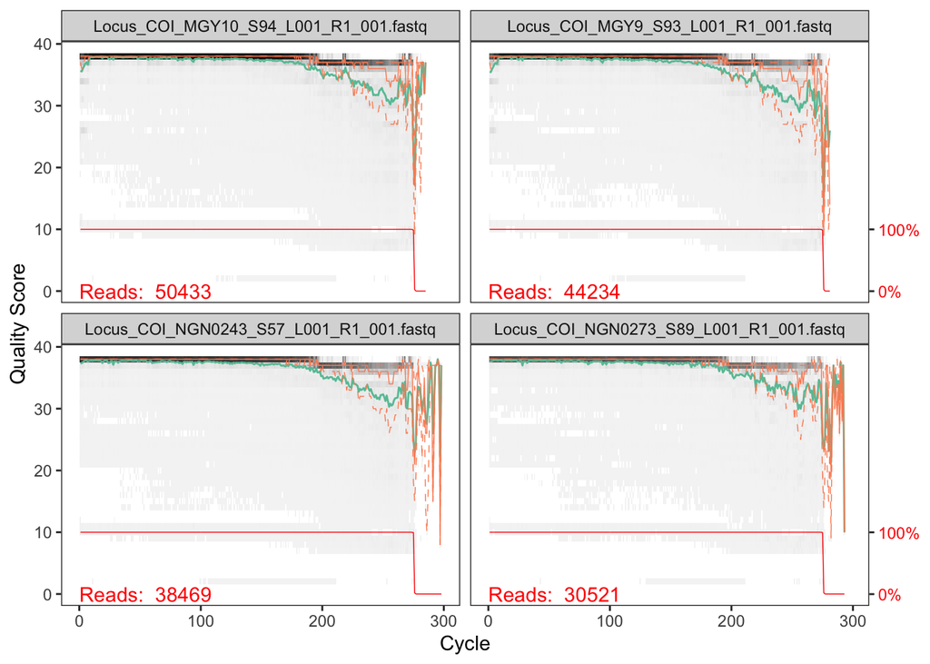

```r
subset %>% pull(file1) %>%
  plotQualityProfile(.)
```

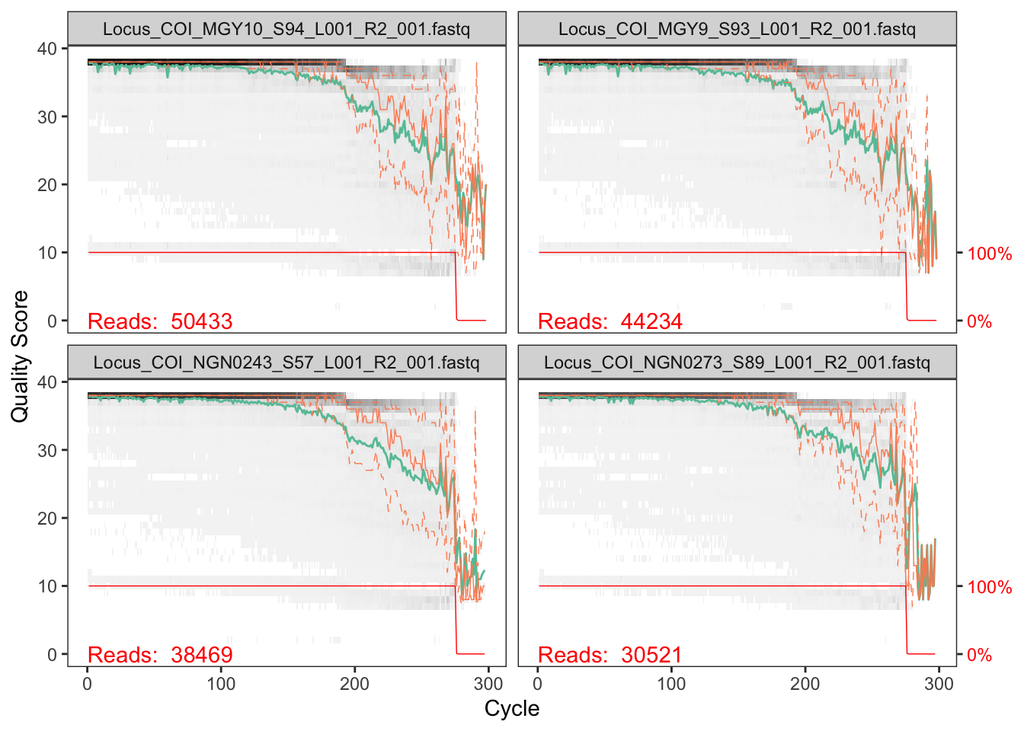

```r
ggsave(file.path(output.dir,"R1_subset.png"))

subset %>% pull(file2) %>%
  plotQualityProfile(.)
```

```r
ggsave(file.path(output.dir,"R2_subset.png"))

# plot aggregate

# sample.metadata %>% pull(file1) %>%
#   plotQualityProfile(., aggregate=TRUE)
#
# sample.metadata %>% pull(file2) %>%
#   plotQualityProfile(., aggregate=TRUE)
```

```r
sample.metadata %>%
  separate(file1, into = "basename", sep= "_L001_R1", remove = F) %>%
  mutate(filtF1 = file.path("filtered", paste0(basename, "_F1_filt.fastq.gz")),
         filtR1 = file.path("filtered", paste0(basename, "_R1_filt.fastq.gz"))) %>%
  select(-basename) %>%
  mutate (outFs = pmap(.l= list (file1, filtF1, file2, filtR1),
                       .f = function(a, b, c, d) {
                         filterAndTrim(a,b,c,d,
                                       truncLen=c(params$trimming.length.Read1,params$trimming.length.Read2),
                                       maxN=0, maxEE=c(2,2), truncQ=2, rm.phix=TRUE,
                                       compress=TRUE, multithread=TRUE )
                       } ),
          errF1 = map(filtF1, ~ learnErrors(.x, multithread=TRUE,verbose = 0)),     # Calculate errors
          errR1 = map(filtR1, ~ learnErrors(.x, multithread=TRUE,verbose = 0)),
          derepF1 = map(filtF1, derepFastq),                   # dereplicate seqs
          derepR1 = map(filtR1, derepFastq),
          dadaF1  = map2(derepF1,errF1, ~ dada(.x, err = .y, multithread = TRUE)),  # dada2
          dadaR1  = map2(derepR1,errR1, ~ dada(.x, err = .y, multithread = TRUE)),
          mergers = pmap(.l = list(dadaF1,derepF1, dadaR1,derepR1),                 # merge things
                         .f = mergePairs )) -> output.dada2
```

```
## Creating output directory: filtered
```

```
## Sample 1 - 32756 reads in 15074 unique sequences.
## Sample 1 - 39892 reads in 17699 unique sequences.
## Sample 1 - 248971 reads in 74497 unique sequences.
## Sample 1 - 33017 reads in 19613 unique sequences.
## Sample 1 - 36420 reads in 19597 unique sequences.
## Sample 1 - 28970 reads in 14925 unique sequences.
## Sample 1 - 31820 reads in 15774 unique sequences.
## Sample 1 - 38662 reads in 19010 unique sequences.
## Sample 1 - 29469 reads in 14357 unique sequences.
## Sample 1 - 28716 reads in 14715 unique sequences.
## Sample 1 - 30500 reads in 16222 unique sequences.
## Sample 1 - 36244 reads in 16853 unique sequences.
## Sample 1 - 15359 reads in 8124 unique sequences.
## Sample 1 - 35789 reads in 16590 unique sequences.
## Sample 1 - 39204 reads in 18360 unique sequences.
## Sample 1 - 33173 reads in 12493 unique sequences.
## Sample 1 - 27373 reads in 11518 unique sequences.
## Sample 1 - 35384 reads in 14258 unique sequences.
## Sample 1 - 36667 reads in 19755 unique sequences.
## Sample 1 - 32832 reads in 18085 unique sequences.
## Sample 1 - 17413 reads in 10551 unique sequences.
## Sample 1 - 36805 reads in 19310 unique sequences.
## Sample 1 - 33028 reads in 18881 unique sequences.
## Sample 1 - 31970 reads in 18833 unique sequences.
## Sample 1 - 35976 reads in 17830 unique sequences.
## Sample 1 - 36368 reads in 17188 unique sequences.
## Sample 1 - 32177 reads in 16036 unique sequences.
## Sample 1 - 35430 reads in 7088 unique sequences.
## Sample 1 - 46242 reads in 21045 unique sequences.
## Sample 1 - 34919 reads in 10944 unique sequences.
## Sample 1 - 33423 reads in 10836 unique sequences.
## Sample 1 - 25747 reads in 7760 unique sequences.
## Sample 1 - 25029 reads in 6884 unique sequences.
## Sample 1 - 35329 reads in 7748 unique sequences.
## Sample 1 - 32498 reads in 7673 unique sequences.
## Sample 1 - 29255 reads in 6190 unique sequences.
## Sample 1 - 33984 reads in 6122 unique sequences.
## Sample 1 - 35055 reads in 16937 unique sequences.
## Sample 1 - 26319 reads in 15039 unique sequences.
## Sample 1 - 41805 reads in 20689 unique sequences.
```

[output cut: 27 more lines]

```
## Sample 1 - 32177 reads in 16345 unique sequences.
## Sample 1 - 35430 reads in 6360 unique sequences.
## Sample 1 - 46242 reads in 18911 unique sequences.
## Sample 1 - 34919 reads in 9160 unique sequences.
## Sample 1 - 33423 reads in 9882 unique sequences.
## Sample 1 - 25747 reads in 6791 unique sequences.
## Sample 1 - 25029 reads in 4407 unique sequences.
## Sample 1 - 35329 reads in 6225 unique sequences.
## Sample 1 - 32498 reads in 8831 unique sequences.
## Sample 1 - 29255 reads in 4973 unique sequences.
## Sample 1 - 33984 reads in 7288 unique sequences.
## Sample 1 - 35055 reads in 16381 unique sequences.
## Sample 1 - 26319 reads in 12324 unique sequences.
## Sample 1 - 41805 reads in 19270 unique sequences.
## Sample 1 - 48017 reads in 21617 unique sequences.
```

```r
if ( params$keep.mid.files==TRUE){
write_rds(output.dada2, path = "output.halfway.rds")}
seqtabF <- makeSequenceTable(output.dada2$mergers)
dim(seqtabF)
```

```
## [1]    41 19738
```

```r
table(nchar(getSequences(seqtabF)))
```

```
##
##  250  251  254  264  267  271  275  277  279  280  283  285  286  287  288  289
##    5    1    1    2    1    3    1    4    1    3    3    1    4    3    1    3
##  290  291  292  295  296  298  300  301  302  303  304  305  306  307  308  309
##    1    2    5   13    2   10   12  109   23   51  848   19   43  346   14   51
##  310  311  312  313  314  315  316  317  318  319  320  321  322  323  325  326
##  389   48  397 9552    8   19  357    3    2   30    4    3   28    4    4    1
##  327  328  331  332  334  336  337  338  339  340  343  347  348  349  350  351
##    2    4    8    1    4    1    8    1    1   39    2    1    6   57    9   75
##  352  354  355  356  357  358  361  364  367  368  370  373  376  381  382  384
## 5644   16 1135    2    4  226    4    7   28    1    1    3    2    1    2    1
##  389  393  405  406  415  432
##    1    2    1    1    1    1
```

Now we will remove chimera sequences. This is done within dada2 but you could use other ways

```r
seqtab.nochim <- removeBimeraDenovo(seqtabF, method="consensus", multithread=TRUE)
dim(seqtab.nochim)
```

```
## [1]    41 19000
```

```r
seqtab.nochim.df <- as.data.frame(seqtab.nochim)
```

```r
# Copy the metadata so it is all in one place
sample.metadata %>% write_csv(file.path(output.dir,"metadata.csv"))

# Output files
  conv_file <- file.path(output.dir,"hash_key.csv")
  conv_file.fasta <- file.path(output.dir,"hash_key.fasta")

  ASV_file <-  file.path(output.dir,"ASV_table.csv")

  print (conv_file)
```

```
## [1] "/Users/elizabethandruszkiewicz/GoogleDrive/UW/GitHub/NextGenNEPA_EA/Output/dada2_output/run3_20211117/COI/hash_key.csv"
```

```r
  print (conv_file.fasta)
```

```
## [1] "/Users/elizabethandruszkiewicz/GoogleDrive/UW/GitHub/NextGenNEPA_EA/Output/dada2_output/run3_20211117/COI/hash_key.fasta"
```

```r
  print(ASV_file)
```

```
## [1] "/Users/elizabethandruszkiewicz/GoogleDrive/UW/GitHub/NextGenNEPA_EA/Output/dada2_output/run3_20211117/COI/ASV_table.csv"
```

```r
if ( params$hash==TRUE)
  {
  conv_table <- tibble( Hash = "", Sequence ="")


   map_chr (colnames(seqtab.nochim.df), ~ digest(.x, algo = "sha1", serialize = F, skip = "auto")) -> Hashes
  conv_table <- tibble (Hash = Hashes,
                        Sequence = colnames(seqtab.nochim.df))

  colnames(seqtab.nochim.df) <- Hashes



  write_csv(conv_table, conv_file) # write the table into a file
  write.fasta(sequences = as.list(conv_table$Sequence),
              names     = as.list(conv_table$Hash),
              file.out = conv_file.fasta)
 seqtab.nochim.df <- bind_cols(sample.metadata %>%
                                select(Sample_name, Locus),
                              seqtab.nochim.df)
seqtab.nochim.df %>%
  pivot_longer(cols = c(- Sample_name, - Locus),
              names_to = "Hash",
              values_to = "nReads") %>%
  filter(nReads > 0) -> current_asv
write_csv(current_asv, ASV_file)    }else{
  #What do we do if you don't want hashes: two things - Change the header of the ASV table, write only one file
   seqtab.nochim.df %>%
  pivot_longer(cols = c(- Sample_name, - Locus),
              names_to = "Sequence",
              values_to = "nReads") %>%
  filter(nReads > 0) -> current_asv
write_csv(current_asv, ASV_file)
}
```

## Track the fate of all reads

```r
getN <- function(x) sum(getUniques(x))

output.dada2 %>%
  select(-file1, -file2, -filtF1, -filtR1, -errF1, -errR1, -derepF1, -derepR1) %>%
  mutate_at(.vars = c("dadaF1", "dadaR1", "mergers"),
            ~ sapply(.x,getN)) %>%
#  pull(outFs) -> test
  mutate(input = map_dbl(outFs, ~ .x[1]),
         filtered = map_dbl(outFs, ~ .x[2]),
         tabled  = rowSums(seqtabF),
         nonchim = rowSums(seqtab.nochim)) %>%
  select(Sample_name,
         Locus,
         input,
         filtered,
         denoised_F = dadaF1,
         denoised_R = dadaR1,
         merged = mergers,
         tabled,
         nonchim) -> track

write_csv(track, file.path(output.dir,"dada2_summary.csv"))
```

```r
if ( params$keep.mid.files==FALSE){
unlink(filt_path, recursive = T)
  }
```

```r
kable (track, align= "c", format = "html") %>%
      kable_styling(bootstrap_options= "striped", full_width = T, position = "center") %>%
      column_spec(2, bold=T)
```

| Sample_name | Locus | input | filtered | denoised_F | denoised_R | merged | tabled | nonchim |
| --- | --- | --- | --- | --- | --- | --- | --- | --- |
| COI.0321.2Brn.Up.2 | COI | 35076 | 32756 | 28577 | 29161 | 26587 | 26587 | 26451 |
| COI.0321.2Brn.Up.2TR2 | COI | 42672 | 39892 | 35320 | 36034 | 33177 | 33177 | 32940 |
| COI.0321.2Brn.Up.2TR3 | COI | 264359 | 248971 | 241989 | 242610 | 235035 | 235035 | 233365 |
| COI.0421.1Prt.Dn.1 | COI | 35361 | 33017 | 28164 | 27612 | 23962 | 23962 | 23819 |
| COI.0421.2Brn.Dn.1 | COI | 38469 | 36420 | 31079 | 32129 | 28618 | 28618 | 28535 |
| COI.0421.2Brn.Dn.2 | COI | 30375 | 28970 | 26012 | 26440 | 24214 | 24214 | 24076 |
| COI.0421.2Brn.Dn.3 | COI | 33614 | 31820 | 26559 | 27433 | 24559 | 24559 | 24104 |
| COI.0421.3Chk.Dn.2 | COI | 40689 | 38662 | 33830 | 34588 | 30990 | 30990 | 29822 |
| COI.0421.3Chk.Dn.3 | COI | 31014 | 29469 | 24491 | 25329 | 22300 | 22300 | 20879 |
| COI.0421.3Chk.Up.1 | COI | 30297 | 28716 | 23302 | 24306 | 20881 | 20881 | 19762 |
| COI.0421.3Chk.Up.2 | COI | 32963 | 30500 | 25643 | 26774 | 23705 | 23705 | 21914 |
| COI.0421.3Chk.Up.3 | COI | 38019 | 36244 | 30652 | 31644 | 27810 | 27810 | 25757 |
| MBT.1m2.072021 | COI | 16311 | 15359 | 14727 | 14658 | 13898 | 13898 | 13691 |
| COI.0421.4Pad.Up11.2 | COI | 37845 | 35789 | 30975 | 31559 | 28346 | 28346 | 28296 |
| MBT.1m3.072021 | COI | 41396 | 39204 | 38510 | 38550 | 37231 | 37231 | 36600 |
| COI.0421.5Sqm.Up.3 | COI | 37032 | 33173 | 28894 | 30010 | 26991 | 26991 | 26661 |
| COI.0421.4Pad.Up11.2TR2 | COI | 28876 | 27373 | 24533 | 25357 | 23464 | 23464 | 22256 |
| COI.0421.4Pad.Up11.2TR3 | COI | 37191 | 35384 | 32117 | 32975 | 30735 | 30735 | 29202 |
| COI.0821.1Prt.Dn.1 | COI | 39332 | 36667 | 32852 | 33411 | 30246 | 30246 | 30223 |
| COI.0821.1Prt.Dn.2 | COI | 35085 | 32832 | 28957 | 29242 | 26241 | 26241 | 26201 |
| COI.0821.1Prt.Up.1 | COI | 18595 | 17413 | 13954 | 14490 | 12471 | 12471 | 12454 |
| COI.0821.2Brn.Dn.1 | COI | 38937 | 36805 | 33042 | 33517 | 30959 | 30959 | 30842 |
| COI.0821.2Brn.Dn.3 | COI | 37071 | 33028 | 29030 | 29970 | 27333 | 27333 | 27175 |
| COI.0821.2Brn.Up.1 | COI | 35015 | 31970 | 28258 | 29406 | 26638 | 26638 | 26600 |
| COI.0821.2Brn.Up.3 | COI | 38157 | 35976 | 31442 | 32223 | 28956 | 28956 | 28921 |
| COI.0821.3Chk.Dn.3 | COI | 38644 | 36368 | 35546 | 35566 | 34772 | 34772 | 34706 |
| COI.0821.3Chk.Up.3 | COI | 35115 | 32177 | 28281 | 28703 | 26223 | 26223 | 25766 |
| COI.0821.4Pad.Dn.2 | COI | 37047 | 35430 | 33858 | 33993 | 33329 | 33329 | 32968 |
| COI.0821.4Pad.Up5.3 | COI | 48894 | 46242 | 41543 | 42555 | 39639 | 39639 | 39247 |
| COI.0821.5Sqm.Dn.1 | COI | 37044 | 34919 | 34020 | 34310 | 32107 | 32107 | 27805 |
| COI.0821.5Sqm.Dn.2 | COI | 35730 | 33423 | 32581 | 32828 | 30988 | 30988 | 27770 |
| COI.0821.5Sqm.Dn.3 | COI | 27349 | 25747 | 25031 | 25292 | 23534 | 23534 | 20519 |
| COI.0821.5Sqm.Up.1 | COI | 26662 | 25029 | 24490 | 24606 | 24244 | 24244 | 23994 |
| COI.0821.5Sqm.Up.3 | COI | 36955 | 35329 | 34629 | 34711 | 34182 | 34182 | 33626 |
| COI.0821.5Sqm.Dn.1TR2 | COI | 34631 | 32498 | 31776 | 31904 | 31309 | 31309 | 30679 |
| COI.0821.5Sqm.Dn.1TR3 | COI | 30521 | 29255 | 28748 | 28776 | 28385 | 28385 | 27990 |
| COI.Kangaroo.Run.3 | COI | 36365 | 33984 | 33883 | 33919 | 33396 | 33396 | 32798 |
| HIP.1m3.072021 | COI | 37305 | 35055 | 34128 | 34282 | 32251 | 32251 | 31726 |
| HIP.15m.0721 | COI | 29723 | 26319 | 25040 | 25159 | 23724 | 23724 | 23288 |
| HIP.30m.0721 | COI | 44234 | 41805 | 39956 | 40062 | 38134 | 38134 | 37451 |
| Delta.BAC1.072021 | COI | 50433 | 48017 | 45748 | 46063 | 41643 | 41643 | 40612 |

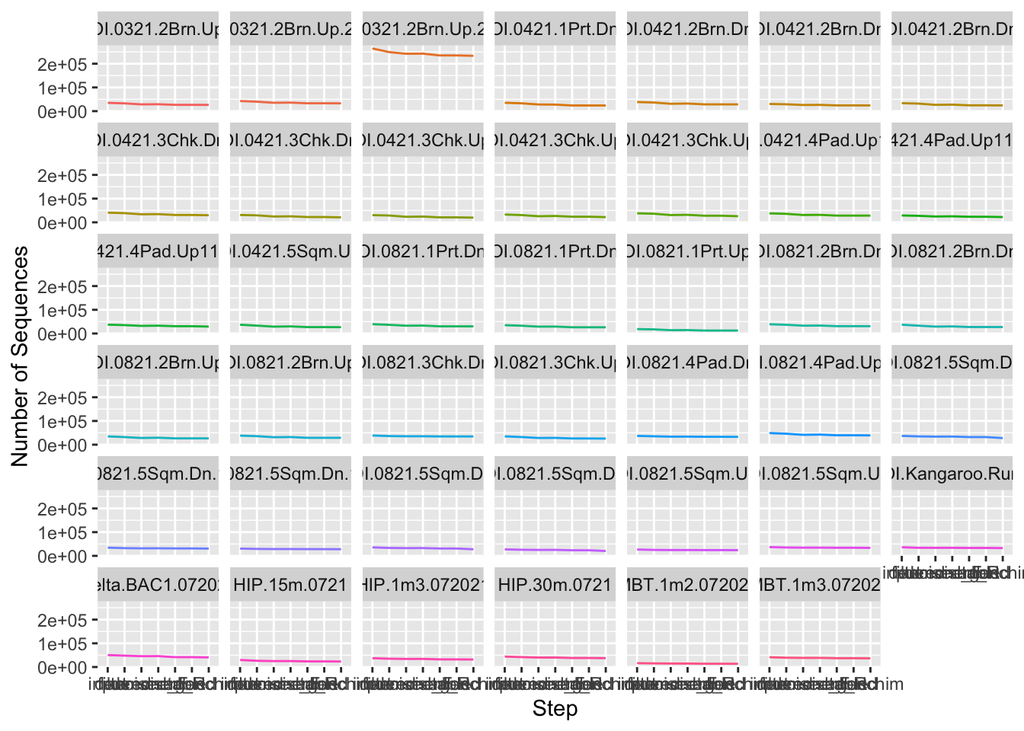

```r
track %>%
  mutate_if(is.numeric, as.integer) %>%
  pivot_longer(cols = c(-Sample_name, -Locus),
               names_to = "Step",
               values_to = "Number of Sequences") %>%
  mutate (Step = fct_relevel(Step,
                             levels = c( "input","filtered","denoised_F" ,"denoised_R" , "merged" , "tabled", "nonchim"))) %>%
  ggplot(aes(x = Step, y = `Number of Sequences`, group =  Sample_name, color = Sample_name)) +
  geom_line() +
  facet_wrap(~Sample_name) +
  guides(color = "none")
```